# Aggregate loss simulation for an insurance portfolio

Rory Jiang

November 10, 2026

## Model and assumptions

Each policy has Poisson claim counts at rate 0.1 per year, so a portfolio of $n$ policies has $N \sim \text{Poisson}(n \cdot \lambda)$ claims. Each claim size is lognormal($\mu$ = 8, $\sigma$ = 1.2), independent of the others and of the count. Total annual loss is $S = X_1 + \dots + X_N$.

Assumptions to keep in mind: all policies are identical, claims are independent, and there is no inflation, no catastrophe correlation and no parameter uncertainty. Real portfolios break each of these.

## Simulate a 1,000-policy portfolio

```r
sim_total <- function(n_pol, lam, meanlog, sdlog, nsim) {
  replicate(nsim, {
    k <- rpois(1, n_pol * lam)
    sum(rlnorm(k, meanlog, sdlog))
  })
}
n_pol <- 1000
S <- sim_total(n_pol, lam, meanlog, sdlog, nsim)
```

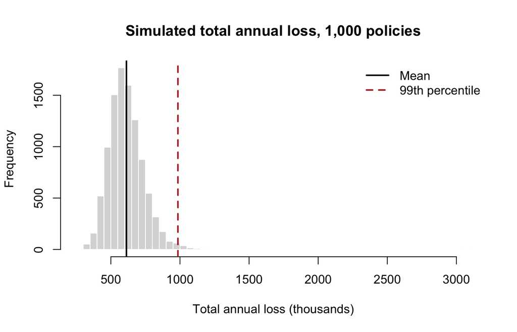

```r
hist(S / 1000, breaks = 60, col = "grey85", border = "white",
     main = "Simulated total annual loss, 1,000 policies",
     xlab = "Total annual loss (thousands)")
abline(v = mean(S) / 1000, lwd = 2)
abline(v = quantile(S, 0.99) / 1000, lty = 2, lwd = 2, col = "firebrick")
legend("topright", legend = c("Mean", "99th percentile"), lty = c(1, 2),
       lwd = 2, col = c("black", "firebrick"), bty = "n")
```

## Check against theory

For a compound Poisson sum with total claim rate $\Lambda = n\lambda$: $E[S] = \Lambda E[X]$ and $\text{Var}(S) = \Lambda E[X^2]$. For a lognormal, $E[X] = e^{\mu + \sigma^2/2}$ and $E[X^2] = e^{2\mu + 2\sigma^2}$.

```r
EX  <- exp(meanlog + sdlog^2 / 2)
EX2 <- exp(2 * meanlog + 2 * sdlog^2)
Lam <- n_pol * lam
check <- data.frame(
  quantity  = c("Mean of S", "Variance of S"),
  simulated = c(mean(S), var(S)),
  theory    = c(Lam * EX, Lam * EX2))
check$pct_diff <- 100 * (check$simulated / check$theory - 1)
knitr::kable(check, digits = 1, format.args = list(big.mark = ","))
```

| quantity | simulated | theory | pct_diff |
| --- | --- | --- | --- |
| Mean of S | 6.125426e+05 | 6.124179e+05 | 0.0 |
| Variance of S | 1.624509e+10 | 1.582996e+10 | 2.6 |

The variance converges more slowly than the mean, because it is driven by the largest simulated claims, and the lognormal tail is heavy.

## Bigger portfolios are more predictable

The coefficient of variation (standard deviation divided by mean) of $S$ should fall like $1/\sqrt{n}$. For this model the exact value is $\text{CV} = e^{\sigma^2/2} / \sqrt{n\lambda}$.

```r
sizes <- c(100, 300, 1000, 3000, 10000)
cv_tab <- data.frame(n_policies = sizes)
cv_tab$cv_sim <- sapply(sizes, function(n) {
  s <- sim_total(n, lam, meanlog, sdlog, nsim)
  sd(s) / mean(s)
})
cv_tab$cv_theory <- exp(sdlog^2 / 2) / sqrt(sizes * lam)
knitr::kable(cv_tab, digits = 3, format.args = list(big.mark = ","))
```

| n_policies | cv_sim | cv_theory |
| --- | --- | --- |
| 100 | 0.659 | 0.650 |
| 300 | 0.369 | 0.375 |
| 1,000 | 0.203 | 0.205 |
| 3,000 | 0.118 | 0.119 |
| 10,000 | 0.064 | 0.065 |

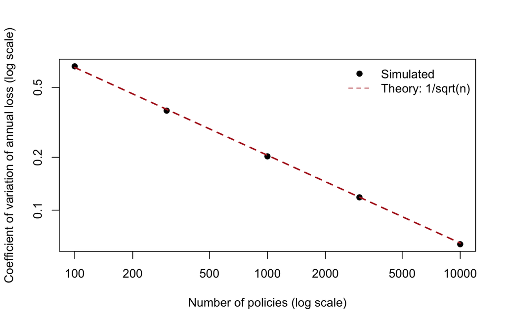

```r
plot(cv_tab$n_policies, cv_tab$cv_sim, log = "xy", pch = 19,
     xlab = "Number of policies (log scale)",
     ylab = "Coefficient of variation of annual loss (log scale)")
lines(cv_tab$n_policies, cv_tab$cv_theory, lty = 2, lwd = 2, col = "firebrick")
legend("topright", legend = c("Simulated", "Theory: 1/sqrt(n)"),
       pch = c(19, NA), lty = c(NA, 2), col = c("black", "firebrick"), bty = "n")
```

```r
slope <- coef(lm(log(cv_sim) ~ log(n_policies), data = cv_tab))[2]
```

The fitted log-log slope is -0.504; a value near $-0.5$ means the $1/\sqrt{n}$ law holds.

## Fit the severity distribution by maximum likelihood

Treat 5,000 simulated claims as observed data and estimate the lognormal parameters. For a lognormal the MLE is closed form: the mean and the (divide-by-n) standard deviation of the log claim sizes.

```r
x <- rlnorm(5000, meanlog, sdlog)
lx <- log(x)
mle <- c(meanlog = mean(lx), sdlog = sqrt(mean((lx - mean(lx))^2)))
lfit <- MASS::fitdistr(x, "lognormal")
gfit <- tryCatch(MASS::fitdistr(x, "gamma"), error = function(e) NULL)
fits <- data.frame(
  family = "Lognormal",
  logLik = as.numeric(logLik(lfit)),
  AIC = AIC(lfit))
if (!is.null(gfit)) {
  fits <- rbind(fits, data.frame(family = "Gamma",
                                 logLik = as.numeric(logLik(gfit)), AIC = AIC(gfit)))
}
knitr::kable(data.frame(parameter = c("meanlog", "sdlog"),
                        truth = c(meanlog, sdlog), closed_form_MLE = mle,
                        fitdistr_estimate = as.numeric(lfit$estimate),
                        std_error = as.numeric(lfit$sd)), digits = 4)
```

|  | parameter | truth | closed_form_MLE | fitdistr_estimate | std_error |
| --- | --- | --- | --- | --- | --- |
| meanlog | meanlog | 8.0 | 7.9830 | 7.9830 | 0.0173 |
| sdlog | sdlog | 1.2 | 1.2218 | 1.2218 | 0.0122 |

```r
knitr::kable(fits, digits = 1)
```

| family | logLik | AIC |
| --- | --- | --- |
| Lognormal | -48011.1 | 96026.2 |

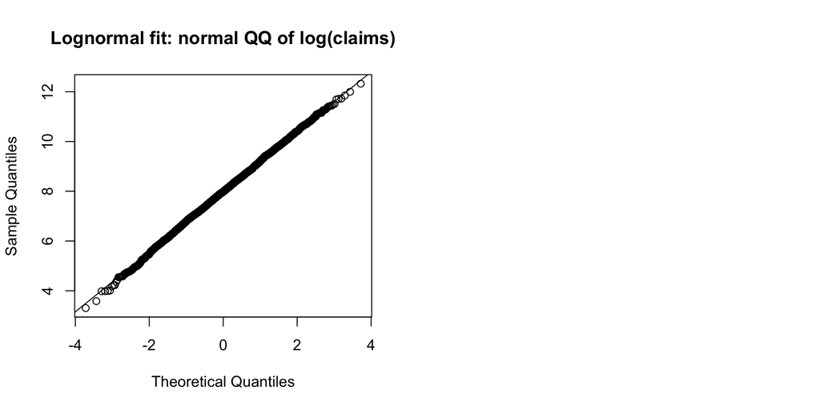

```r
par(mfrow = c(1, 2))
qqnorm(lx, main = "Lognormal fit: normal QQ of log(claims)")
qqline(lx)
if (!is.null(gfit)) {
  q <- qgamma(ppoints(length(x)), shape = gfit$estimate["shape"],
              rate = gfit$estimate["rate"])
  plot(q, sort(x), log = "xy", main = "Gamma fit: QQ plot",
       xlab = "Gamma quantiles", ylab = "Observed claims")
  abline(0, 1, col = "firebrick")
}
par(mfrow = c(1, 1))
```

A Kolmogorov-Smirnov test with parameters estimated from the same data is too lenient, so I get the p-value by parametric bootstrap instead: simulate from the fitted model, refit, and see how often the KS statistic is as large as the observed one.

```r
ks_stat <- function(y, m, s) unname(ks.test(y, "plnorm", m, s)$statistic)
obs <- ks_stat(x, mle["meanlog"], mle["sdlog"])
boot_ks <- replicate(500, {
  y <- rlnorm(length(x), mle["meanlog"], mle["sdlog"])
  ly <- log(y)
  ks_stat(y, mean(ly), sqrt(mean((ly - mean(ly))^2)))
})
p_boot <- mean(boot_ks >= obs)
```

## Deductible and aggregate stop-loss

A per-claim deductible $d$ makes the insurer pay $\max(X - d, 0)$ on each claim. An aggregate stop-loss with limit $L$ makes the insurer retain $\min(S, L)$ and the reinsurer pay $(S - L)_+$. I apply both to the same simulated years.

```r
d <- 5000
sim_both <- function(n_pol, lam, meanlog, sdlog, nsim, d) {
  out <- replicate(nsim, {
    k <- rpois(1, n_pol * lam)
    x <- rlnorm(k, meanlog, sdlog)
    c(gross = sum(x), net_ded = sum(pmax(x - d, 0)))
  })
  t(out)
}
sims <- sim_both(n_pol, lam, meanlog, sdlog, nsim, d)
L <- unname(quantile(sims[, "gross"], 0.95))
scen <- list(
  "Gross (no layers)"              = sims[, "gross"],
  "Per-claim deductible"           = sims[, "net_ded"],
  "Stop-loss only"                 = pmin(sims[, "gross"], L),
  "Deductible + stop-loss"         = pmin(sims[, "net_ded"], L))
layers <- data.frame(
  scenario = names(scen),
  mean = sapply(scen, mean),
  sd   = sapply(scen, sd),
  p99  = sapply(scen, quantile, probs = 0.99))
rownames(layers) <- NULL
knitr::kable(layers, digits = 0, format.args = list(big.mark = ","))
```

| scenario | mean | sd | p99 |
| --- | --- | --- | --- |
| Gross (no layers) | 612,077 | 125,032 | 971,634 |
| Per-claim deductible | 309,829 | 105,799 | 628,878 |
| Stop-loss only | 608,024 | 114,767 | 833,407 |
| Deductible + stop-loss | 309,785 | 105,553 | 628,878 |

The deductible is 5,000 per claim; the stop-loss limit is the 95th percentile of gross annual loss, 833,407. The expected amount the reinsurer pays above that limit is 4,053.

## How well can the 99th percentile be estimated?

The 99th percentile is a typical capital metric, but it is hard to estimate from a short history. I draw histories of different lengths (years) from the simulated annual losses, bootstrap the 99th percentile of each, and compare with a 100,000-year simulation as the reference.

```r
set.seed(7)
truth <- unname(quantile(sim_total(n_pol, lam, meanlog, sdlog, 100000), 0.99))
boot_ci <- function(y, B = 1000) {
  b <- replicate(B, quantile(sample(y, replace = TRUE), 0.99))
  c(estimate = unname(quantile(y, 0.99)),
    lo = unname(quantile(b, 0.025)), hi = unname(quantile(b, 0.975)))
}
ms <- c(20, 100, 1000, 10000)
res <- data.frame(years_of_history = ms,
                  t(sapply(ms, function(m) boot_ci(sample(S, m)))))
res$reference <- truth
res$interval_width_pct_of_reference <- 100 * (res$hi - res$lo) / truth
knitr::kable(res, digits = 0, format.args = list(big.mark = ","))
```

| years_of_history | estimate | lo | hi | reference | interval_width_pct_of_reference |
| --- | --- | --- | --- | --- | --- |
| 20 | 801,237 | 742,986 | 803,717 | 968,478 | 6 |
| 100 | 961,692 | 843,554 | 1,022,922 | 968,478 | 19 |
| 1,000 | 950,231 | 898,431 | 1,021,920 | 968,478 | 13 |
| 10,000 | 985,083 | 969,576 | 1,000,501 | 968,478 | 3 |

## Conclusions

Numbers below are from the run with seed 2026.

- **Theory check.** Simulated mean matched theory (0.0% difference); simulated variance was 2.6% above theory, about what sampling error allows for a heavy-tailed sum.
- **Diversification.** The coefficient of variation of annual loss falls like $1/\sqrt{n}$ (fitted log-log slope -0.504). The relative variability shrinks as the book grows, but only because policies are assumed independent and identical.
- **Severity fit.** Maximum likelihood recovered the lognormal parameters (7.983 vs 8, 1.222 vs 1.2); a parametric-bootstrap KS test gave p = 0.33.
- **Deductible.** A 5,000 per-claim deductible cut expected loss 49% and the 99th percentile 35%, but raised the coefficient of variation from 0.20 to 0.34.
- **Stop-loss.** A limit at the 95th percentile of gross loss (833,407) cost the reinsurer 4,053 in expected payments (0.66% of the mean) and cut the 99th percentile by 14%. Combined with the deductible it never bound at the 99th percentile, so limits should be set against the retained distribution.
- **Tail estimation.** From 20 years of history the 99th-percentile estimate was 17% below the 100,000-year reference, with a narrow interval that missed it. From 100 years the interval was 19% wide. Short histories cannot pin down tail risk, which is why frequency and severity models are fitted and simulated instead.

Limitations: identical independent policies, no inflation, no catastrophe correlation, no parameter uncertainty, and severity parameters chosen by me rather than estimated from data.